# Tutorial: Machine Learning in R

W. Evan Johnson

2026-09-15

## Set up: load these packages!

```r
library(caret)
library(DT)
library(tidyverse)
library(e1071)
library(gridExtra)
library(mda)
library(randomForest)
```

## Introduction

To get started, you will need the following dependencies (R packages to install and datasets to download):

1. Install R and R Studio
2. Please install the following R packages for Data Management: `tidyverse`, `DT`, and `gridExtra`. In R:

```r
install.packages(c("tidyverse", "DT", "gridExtra"))
```

3. Please install the following R packages for Machine learning: `umap`, `mda` `caret`, `e1071`, `rpart`, `randomForest`, `neuralnet`. In R:

```r
install.packages(c("caret", "e1071", "rpart", "randomForest"))
```

4. You will need the following datasets: `heights.rds`, `olive.rds`, and `TBnanostring.rds`

## Data Frames

A large proportion of data analysis challenges start with data stored in a data frame. For example, we stored the data for our motivating example in a data frame. You can access this dataset by loading `TBNanostring.rds` object in R:

```r
TBnanostring <- readRDS("TBnanostring.rds")
```

In RStudio we can view the data with the `View` function:

```r
View(TBnanostring)
```

Or in RMarkdown you can use the `datatable` function from the `DT` package:

```r
datatable(TBnanostring)
```

|  | TB_Status | AGAP9 | AIRE | ANKRD22 | APOL1 | APOL6 | ATP1A1 | BATF2 | BCL6 | BLK | C16orf7 | C1QB | C1QC | C4ORF18 | C5 | CCDC14 | CCDC78 | CCR6 | CD1C | CD79A | CD79B | CIRBP | CTSA | CXCR5 | CXorf40B | CYP4F3 | DARS2 | DERA | DUSP3 | … |
| --- | --- | --- | --- | --- | --- | --- | --- | --- | --- | --- | --- | --- | --- | --- | --- | --- | --- | --- | --- | --- | --- | --- | --- | --- | --- | --- | --- | --- | --- | --- |
| Sample_1 | TB | -0.3567952891613851 | -0.2428400750618191 | 1.207905558493485 | 1.555417591919483 | 1.253195633963252 | -1.19773967725765 | 1.267449740074419 | 1.44405564668365 | 0.08830775445314894 | 2.019266536890396 | 0.7516975319176218 | 0.3728128299227613 | -1.044097012784921 | -0.6537817263494731 | -0.6655872996869874 | 0.3941787796749492 | -0.731969022018938 | 0.2519854285556507 | 0.1100454335247583 | 0.02071439218469675 | -0.3212363894966508 | -1.149180848797646 | 0.3352513020122072 | -0.5414855353359561 | 1.274072363654428 | -0.1299396035972255 | -2.397303286864058 | 0.2299788779102083 | … |
| Sample_2 | TB | -0.5855965092374802 | -1.306416297601576 | 1.216041831341325 | 0.5208883402769555 | -0.07293285737957687 | -1.090330219535047 | 0.3970186823102559 | 0.5046354934802626 | -1.668252626535817 | 1.699008243667597 | 1.266415983002439 | 1.397989287308514 | 0.7745526015112829 | 0.5992139442150497 | -1.543550285725023 | 0.004670462482051654 | -1.484418435922324 | 0.3703776259266084 | -2.017855314157253 | -1.50285848270686 | -1.029017144667262 | 1.144979693267663 | -1.591693600854994 | -0.650163550455721 | 0.9066523154368646 | -0.9552105910616149 | 0.5002664813531675 | 1.186088490147909 | … |
| Sample_3 | TB | -0.7078443755887588 | 0.4544570754679451 | 0.1840317405129417 | 0.9494341145965206 | 1.644055869109122 | 0.502818498776224 | 0.5904435779994958 | 0.2033804354046358 | -1.052170149038109 | 0.1905297652957624 | 0.1035590670298391 | 0.002535352876393561 | 1.497504717120949 | 1.111576237536498 | -0.8580099443371357 | -0.675949760725112 | -0.9478361361919522 | -1.131327775946374 | -0.9823028457157846 | -1.345413654355336 | -0.550787253089989 | 1.197782679137242 | -0.9561950288944006 | -0.4921720574098309 | 0.1244443090172449 | -0.7795466235788089 | -0.6559051562414868 | 0.6930788083993142 | … |
| Sample_4 | TB | -1.031494667575215 | -0.600953084668492 | 1.628997686518667 | 2.075581508023125 | 1.823098909982189 | -1.307260034784574 | 1.376982284915563 | 1.847995219384217 | -1.361940589988246 | 2.524736151391167 | 0.755247441115648 | 0.3101495804997122 | 1.163219685390775 | -1.211930639904139 | -1.689793585506124 | 0.5001794710387819 | -1.10819211956498 | -1.193657466264923 | -1.112137911596951 | -1.33186843527569 | -0.7038541523416637 | 0.5308060675652948 | -1.099250316818298 | -0.9543184887761932 | 0.4315414607187606 | -2.026026663896097 | -0.7080736613811327 | 2.244592066682114 | … |
| Sample_5 | TB | 0.9067240290496833 | -0.1348924583178322 | -1.246894792845696 | -1.909669345338767 | -1.884188394186358 | 0.5920268788386729 | -1.565009666862524 | 0.2623956965346229 | 0.820643298328746 | -0.6990454334548679 | -1.083580214103867 | -0.6644456998932498 | 1.952931401028057 | 0.2914324531183866 | 0.8068929732375072 | 0.3842083479338066 | 1.088422222794646 | 1.249115329733536 | 0.9866711547788964 | 0.9104379020429241 | 0.3096601100166029 | -0.1476334293752958 | 0.8238985049492284 | 0.5323003625478224 | -0.004769889750576167 | 0.6436695769010405 | 1.619851589921788 | 0.2219999392611381 | … |
| Sample_6 | TB | -1.83851797105418 | -0.1280090784823144 | 0.8316545568380391 | 1.545006176944255 | 0.7208395835658897 | -1.791034149237936 | 1.348357662074938 | 1.147202275569644 | -1.456526606519168 | 1.041255815744687 | 1.063157431296947 | 0.5869006815956217 | 0.1411222404339071 | 0.4314394118862134 | -1.099506015673339 | -1.109208522979346 | -0.8445763418653442 | -1.513864896772926 | -1.772087484684398 | -1.745419947274584 | -1.684252106610131 | 0.7902316529489498 | -1.834249440392554 | -2.109834739591115 | -0.1924586523473725 | -2.314056444090808 | -0.4059249727368296 | 1.014671428328334 | … |
| Sample_7 | TB | 0.05707858493869713 | -1.069854815292915 | 1.189719488865898 | 0.5402351126887245 | 0.7031789856392341 | -0.3818936938393588 | 0.3827145880386386 | 0.8829995825248439 | -0.7671685890744196 | 0.4830399349631236 | -0.5537144551966539 | -0.2835549663622023 | 0.4692120867406758 | -0.1797230425235556 | -0.5594571787153348 | 0.6181745797269812 | -0.9181663430658387 | -0.4642661301471259 | -0.5040647744700524 | -0.4370386919607227 | 1.016509577140669 | -0.1904821171775223 | -0.4032354212848691 | 0.4023719199114419 | 2.167110090536964 | -0.1801868239153136 | -0.6521957193814021 | -0.6645721100370381 | … |
| Sample_8 | TB | -1.883431240167627 | -0.3126381478393918 | 1.50828543722368 | 0.640879601402786 | 2.013017835850941 | -2.172355556174608 | 1.538902864967792 | 0.1354778929013789 | -1.597201021442571 | 1.001035121012908 | 0.9860346466697851 | 0.5004784541589815 | 2.048798646933404 | 0.415294373849733 | -1.257503350664715 | 0.06130851992982272 | -1.950098254224667 | -0.9548917291379766 | -2.009115587082828 | -2.205184564841673 | -1.395130230563012 | -0.6037633826390437 | -2.0294814108926 | -0.01456281910193487 | 0.3890934324866815 | -1.338975631149127 | -2.174430969936838 | 0.2151384800074111 | … |
| Sample_9 | TB | -1.420386185986475 | 0.515383912267111 | 2.610736305246323 | 2.290270059911697 | 2.319317923810889 | -1.455672628594579 | 2.579743829161462 | 0.6216968649724902 | -1.825897128894175 | 1.524702707602241 | 2.241698148500488 | 2.236351022920394 | 0.6611313274262467 | 1.71147702236411 | -0.8662274369939202 | 0.1874593189327216 | -1.231761445517768 | -2.792921964006282 | -1.568631440608613 | -2.074186261695775 | -1.376791283756899 | 1.411948406363706 | -1.644780614603827 | -1.646583654183484 | 0.009585044330324512 | -1.40905778549676 | -1.238000970587481 | 2.511139673095197 | … |
| Sample_10 | TB | -1.38629357623991 | 0.4353941807468526 | 1.785281524644318 | 1.802817415598585 | 2.251563891720713 | -1.607405208737903 | 1.837433876454194 | 1.030657791301887 | -1.470958653056692 | 1.102376348186373 | 1.202236468820842 | 1.277364549709066 | 0.2999661591271855 | 1.423920466821625 | -1.199193801551537 | -0.1949666172492625 | -1.335260518417128 | -1.314502010055313 | -1.214617477447743 | -1.809972298861618 | -1.88626746616501 | 0.4951357059648722 | -1.568400619543112 | -1.519260006773639 | 0.596428364048616 | -1.774390528190914 | -1.811676935566049 | 1.057072629238347 | … |

[output cut: 169 more lines]

You will notice that the TB status is found in the first column of the data frame, followed by the genes in the subsequent columns. The rows represent each individual patient.

## Using the `caret` package

The `caret` package in R has several useful functions for building and assessing machine learning methods. It tries to consolidate many machine learning tools to provide a consistent syntax.

### Using the height data

For a first example, we use the height data in dslabs:

```r
heights <- readRDS("heights.rds")
datatable(heights)
```

|  | sex | height |
| --- | --- | --- |
| 1 | Male | 75 |
| 2 | Male | 70 |
| 3 | Male | 68 |
| 4 | Male | 74 |
| 5 | Male | 61 |
| 6 | Female | 65 |
| 7 | Female | 66 |
| 8 | Female | 62 |
| 9 | Female | 66 |
| 10 | Male | 67 |

[output cut: 1040 more lines]

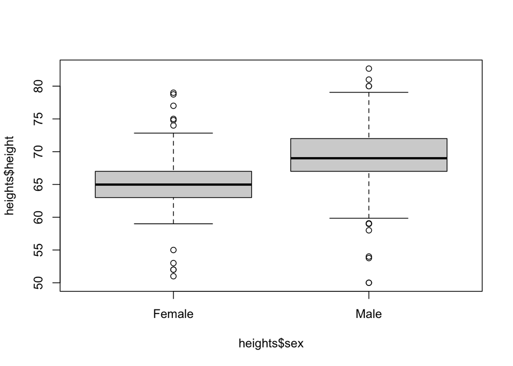

```r
boxplot(heights$height ~ heights$sex)
```

### Partition dataset

The `caret` package includes the function `createDataPartition` that helps us generates indexes for randomly splitting the data into training and test sets:

```r
set.seed(2007)
test_index <- createDataPartition(heights$sex, times = 1,
                                  p = 0.5, list = FALSE)
test_set <- heights[test_index, ]
train_set <- heights[-test_index, ]
```

The argument `times` is used to define how many random samples of indexes to return, `p` is used to define what proportion of the data is represented by the index, and `list` is used to decide if we want the indexes returned as a list or not.

### Simple predictor

Exploratory data analysis suggests we can because, on average, males are slightly taller than females:

```r
heights %>% group_by(sex) %>%
  summarize(mean(height), sd(height))
```

```
## # A tibble: 2 × 3
##   sex    `mean(height)` `sd(height)`
##   <fct>           <dbl>        <dbl>
## 1 Female           64.9         3.76
## 2 Male             69.3         3.61
```

Let’s try predicting with a simple approach: predict `Male` if height is within two standard deviations from the average male. The overall accuracy is 0.78 in the test set:

```r
pred_test <- ifelse(test_set$height > 62, "Male", "Female") %>%
  factor(levels = levels(test_set$sex))
confusionMatrix(pred_test, test_set$sex)
```

```
## Confusion Matrix and Statistics
##
##           Reference
## Prediction Female Male
##     Female     22   18
##     Male       97  388
##
##                Accuracy : 0.781
##                  95% CI : (0.7431, 0.8156)
##     No Information Rate : 0.7733
##     P-Value [Acc > NIR] : 0.3607
##
##                   Kappa : 0.1836
##
##  Mcnemar's Test P-Value : 3.502e-13
##
##             Sensitivity : 0.18487
##             Specificity : 0.95567
##          Pos Pred Value : 0.55000
##          Neg Pred Value : 0.80000
##              Prevalence : 0.22667
##          Detection Rate : 0.04190
##    Detection Prevalence : 0.07619
##       Balanced Accuracy : 0.57027
##
##        'Positive' Class : Female
##
```

### Use the `train` function

The `caret` package currently includes 237+ different machine learning methods, which can be applied using the `train` function. These are summarized in the [`caret` package manual](https://topepo.github.io/caret/available-models.html).

Keep in mind that `caret` does not include the needed packages and, to implement a package through `caret`, you still need to install the library. For example:

```r
height_glm <- train(sex ~ height, method = "glm", data=train_set)
confusionMatrix(predict(height_glm, train_set),
                train_set$sex)
```

```
## Confusion Matrix and Statistics
##
##           Reference
## Prediction Female Male
##     Female     61   18
##     Male       58  388
##
##                Accuracy : 0.8552
##                  95% CI : (0.8222, 0.8842)
##     No Information Rate : 0.7733
##     P-Value [Acc > NIR] : 1.679e-06
##
##                   Kappa : 0.5314
##
##  Mcnemar's Test P-Value : 7.691e-06
##
##             Sensitivity : 0.5126
##             Specificity : 0.9557
##          Pos Pred Value : 0.7722
##          Neg Pred Value : 0.8700
##              Prevalence : 0.2267
##          Detection Rate : 0.1162
##    Detection Prevalence : 0.1505
##       Balanced Accuracy : 0.7341
##
##        'Positive' Class : Female
##
```

## SVMs (Linear)

### Generate dataset

First generate some data in 2 dimensions, and make them a little separated:

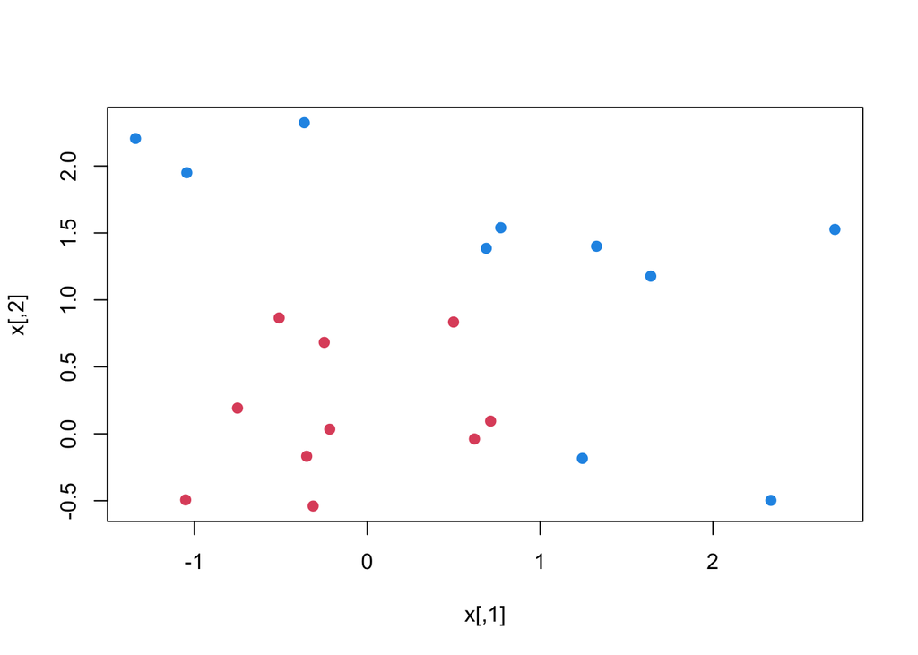

```r
set.seed(10111)
x = matrix(rnorm(40), 20, 2)
y = rep(c(-1, 1), c(10, 10))
x[y == 1,] = x[y == 1,] + 1
plot(x, col = y + 3, pch = 19)
```

### Apply SVM

We will use the **e1071** package which contains the `svm` function that works on the dataframe ($y$ needs to be a factor variable). Printing the svmfit gives its summary.

```r
dat = data.frame(x, y = as.factor(y))
svmfit = svm(y ~ ., data = dat, kernel = "linear", cost = 10, scale = FALSE)
print(svmfit)
```

```
##
## Call:
## svm(formula = y ~ ., data = dat, kernel = "linear", cost = 10, scale = FALSE)
##
##
## Parameters:
##    SVM-Type:  C-classification
##  SVM-Kernel:  linear
##        cost:  10
##
## Number of Support Vectors:  6
```

You can see that the number of support vectors is 6 - they are the points that are close to the boundary or on the wrong side of the boundary.

### Plot SVM (version 1)

There’s a generic plot function for SVM that shows the decision boundary, as you can see below. It doesn’t seem there’s much control over the colors. It breaks with convention since it puts x2 on the horizontal axis and x1 on the vertical axis.

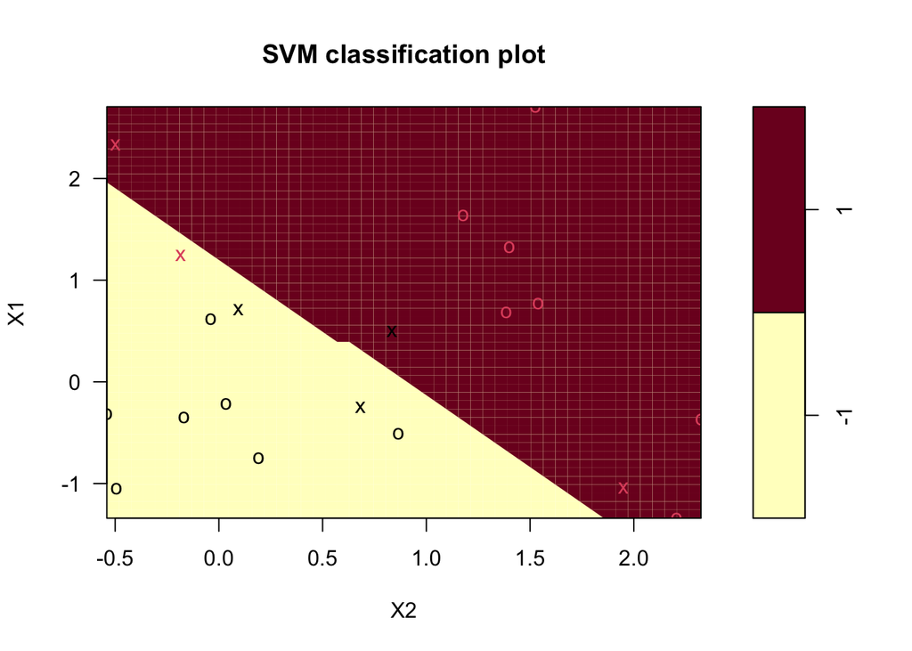

```r
plot(svmfit, dat)
```

### Plot SVM (version 2)

Or plotting it more cleanly:

```r
make.grid = function(x, n = 75) {
  grange = apply(x, 2, range)
  x1 = seq(from = grange[1,1], to = grange[2,1], length = n)
  x2 = seq(from = grange[1,2], to = grange[2,2], length = n)
  expand.grid(X1 = x1, X2 = x2)
}
xgrid = make.grid(x)
```

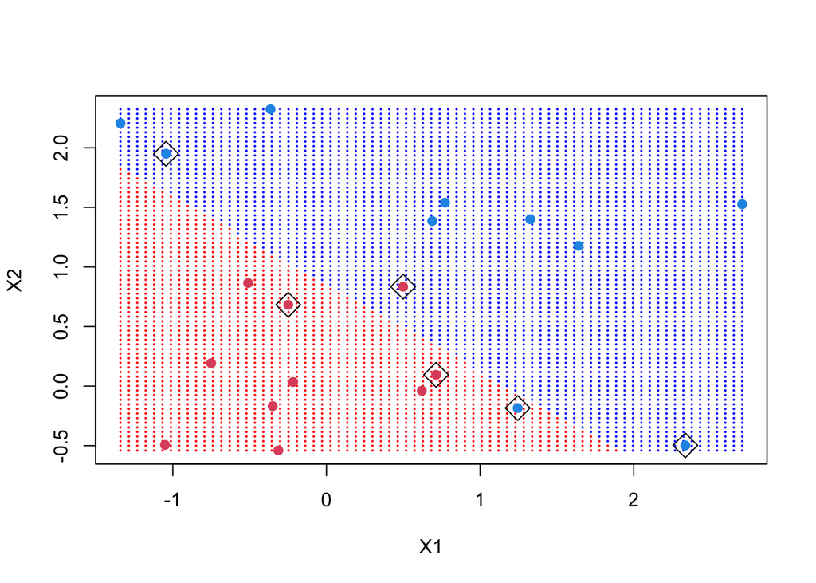

```r
ygrid = predict(svmfit, xgrid)
plot(xgrid, col = c("red","blue")[as.numeric(ygrid)], pch = 20, cex = .2)
points(x, col = y + 3, pch = 19)
points(x[svmfit$index,], pch = 5, cex = 2)
```

Unfortunately, the svm function is not too friendly, in that you have to do some work to get back the linear coefficients. The reason is probably that this only makes sense for linear kernels, and the function is more general. So let’s use a formula to extract the coefficients more efficiently. You extract $\beta$ and $\beta_0$, which are the linear coefficients.

```r
beta = drop(t(svmfit$coefs)%*%x[svmfit$index,])
beta0 = svmfit$rho
```

Now you can replot the points on the grid, then put the points back in (including the support vector points). Then you can use the coefficients to draw the decision boundary using a simple equation of the form:

$$\beta_0+x_1\beta_1+x_2\beta_2=0$$

Now plotting the lines on the graph:

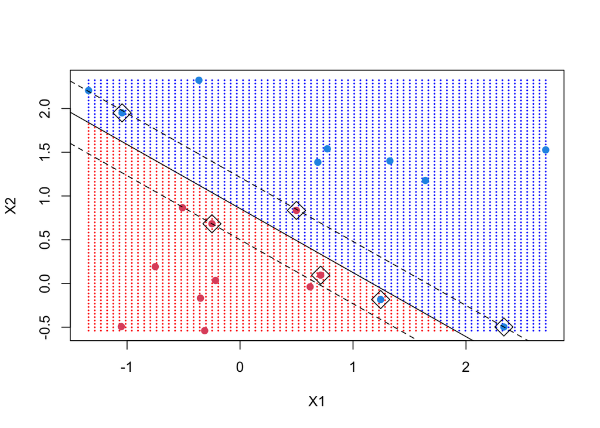

```r
plot(xgrid, col = c("red", "blue")[as.numeric(ygrid)], pch = 20, cex = .2)
points(x, col = y + 3, pch = 19)
points(x[svmfit$index,], pch = 5, cex = 2)
abline(beta0 / beta[2], -beta[1] / beta[2])
abline((beta0 - 1) / beta[2], -beta[1] / beta[2], lty = 2)
abline((beta0 + 1) / beta[2], -beta[1] / beta[2], lty = 2)
```

### SVM Nanostring data

Remember the PCA dimension reduction of the TB Nanostring dataset. The points are colored based on TB status.

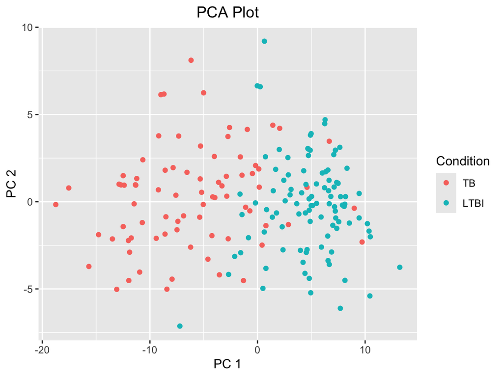

Now let’s try an SVM on the PCs of the Nanostring data

```r
# use only the first 2 PCs
dat = data.frame(y = pca_reduction$Condition,
                 pca_reduction[,1:2])

fit = svm(y ~ ., data = dat, scale = FALSE,
          kernel = "linear", cost = 10)
print(fit)
```

```
##
## Call:
## svm(formula = y ~ ., data = dat, kernel = "linear", cost = 10, scale = FALSE)
##
##
## Parameters:
##    SVM-Type:  C-classification
##  SVM-Kernel:  linear
##        cost:  10
##
## Number of Support Vectors:  52
```

We can evaluate the predictor with a `Confusion matrix`:

```r
confusionMatrix(dat$y,predict(fit,dat))
```

```
## Confusion Matrix and Statistics
##
##           Reference
## Prediction TB LTBI
##       TB   69   10
##       LTBI  8   92
##
##                Accuracy : 0.8994
##                  95% CI : (0.8457, 0.9393)
##     No Information Rate : 0.5698
##     P-Value [Acc > NIR] : <2e-16
##
##                   Kappa : 0.7955
##
##  Mcnemar's Test P-Value : 0.8137
##
##             Sensitivity : 0.8961
##             Specificity : 0.9020
##          Pos Pred Value : 0.8734
##          Neg Pred Value : 0.9200
##              Prevalence : 0.4302
##          Detection Rate : 0.3855
##    Detection Prevalence : 0.4413
##       Balanced Accuracy : 0.8990
##
##        'Positive' Class : TB
##
```

Plotting Nanostring data:

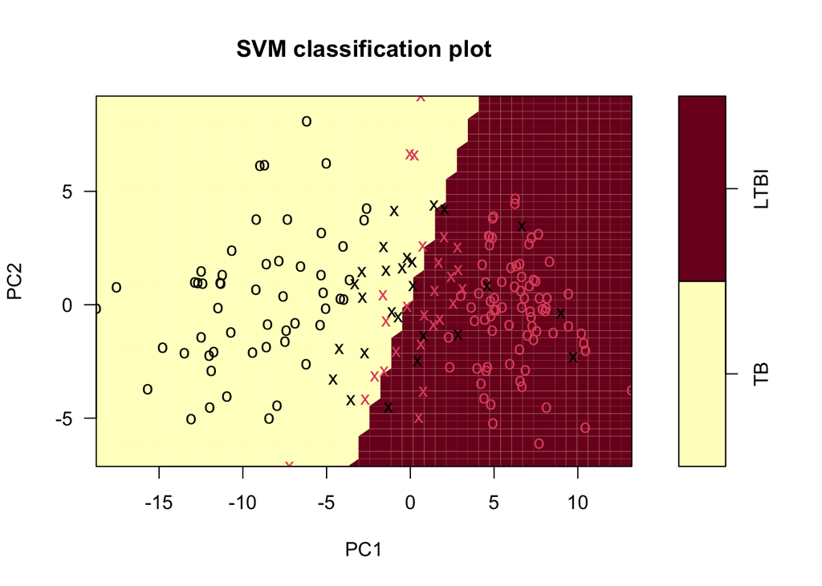

```r
plot(fit,dat,PC2~PC1)
```

And plotting the results more cleanly:

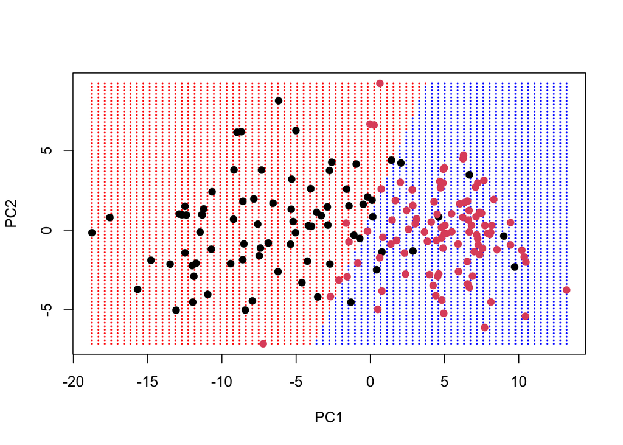

## SVMs (Non-linear)

### Example 1 (polynomial kernel)

#### Apply polynomial SVM

Now let’s apply a non-linear (polynomial) SVM to our prior simulated dataset.

```r
dat = data.frame(x, y = as.factor(y))
svmfit = svm(y ~ ., data = dat,
             kernel = "polynomial", cost = 10, scale = FALSE)
print(svmfit)
```

```
##
## Call:
## svm(formula = y ~ ., data = dat, kernel = "polynomial", cost = 10,
##     scale = FALSE)
##
##
## Parameters:
##    SVM-Type:  C-classification
##  SVM-Kernel:  polynomial
##        cost:  10
##      degree:  3
##      coef.0:  0
##
## Number of Support Vectors:  4
```

#### Plot results

Plotting the result:

[figure not shown]

### Example 2 (radial basis kernel)

#### Load data

Here is a more complex example from *Elements of Statistical Learning* (from the `mda` R package), where the decision boundary needs to be non-linear and there is no clear separation.

```r
rm(x,y)
data(ESL.mixture)
attach(ESL.mixture)
names(ESL.mixture)
```

```
## [1] "x"        "y"        "xnew"     "prob"     "marginal" "px1"      "px2"
## [8] "means"
```

#### Plotting the data:

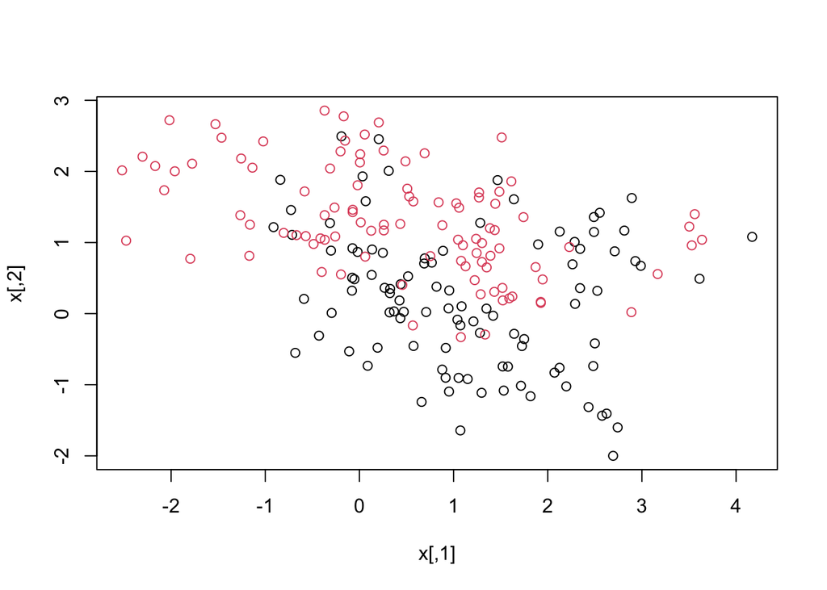

```r
plot(x, col = y + 1)
```

#### Apply SVM (radial basis kernel)

Now make a data frame with the response $y$, and turn that into a factor. We will fit an SVM with radial kernel.

```r
dat = data.frame(y = factor(y), x)
fit = svm(factor(y) ~ ., data = dat, scale = FALSE,
          kernel = "radial", cost = 5)
print(fit)
```

```
##
## Call:
## svm(formula = factor(y) ~ ., data = dat, kernel = "radial", cost = 5,
##     scale = FALSE)
##
##
## Parameters:
##    SVM-Type:  C-classification
##  SVM-Kernel:  radial
##        cost:  5
##
## Number of Support Vectors:  103
```

#### Plotting the result

It’s time to create a grid and predictions. We use `expand.grid` to create the grid, predict each of the values on the grid, and plot them:

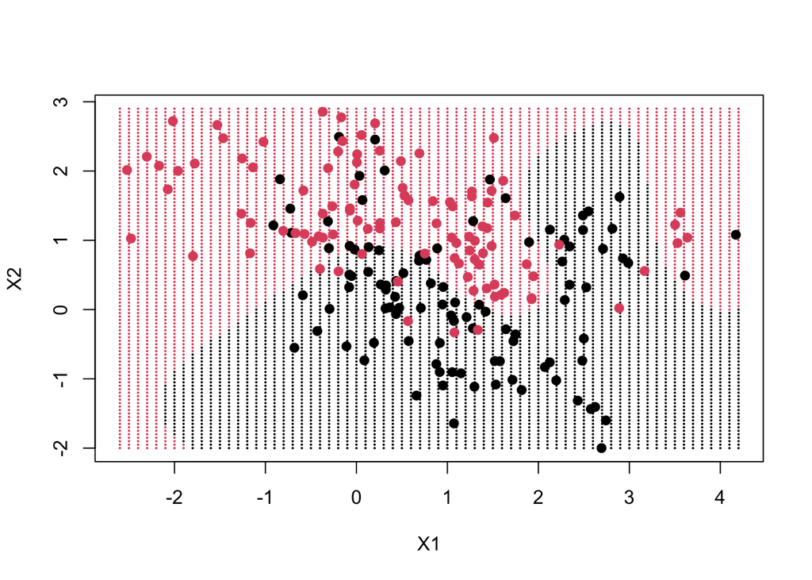

```r
xgrid = expand.grid(X1 = px1, X2 = px2)
ygrid = predict(fit, xgrid)
plot(xgrid, col = as.numeric(ygrid), pch = 20, cex = .2)
points(x, col = y + 1, pch = 19)
```

Plotting with a contour:

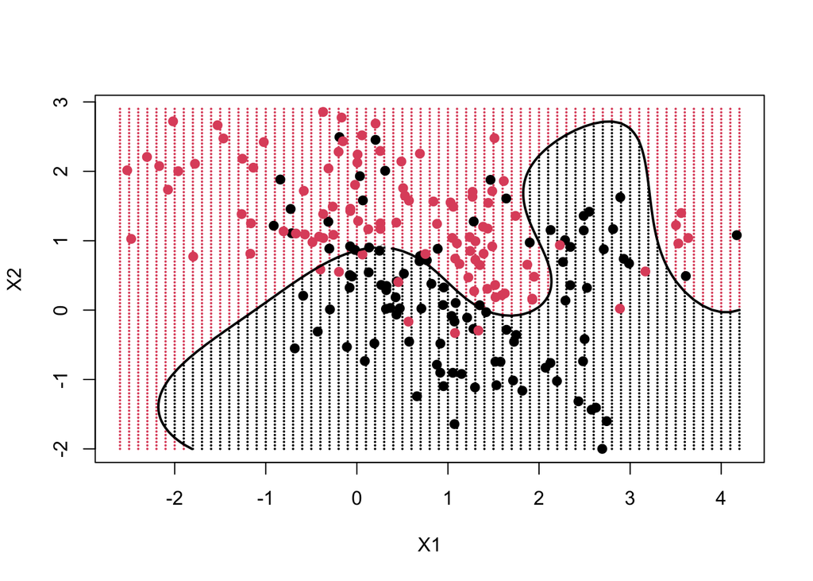

## Decision Trees

### Olive oil

We will use a new dataset that includes the breakdown of the composition of olive oil into 8 fatty acids:

```r
olive <- readRDS("olive.rds")
olive <- select(olive, -area) #remove the `area` column--don't use it
olive %>% datatable()
```

|  | region | palmitic | palmitoleic | stearic | oleic | linoleic | linolenic | arachidic | eicosenoic |
| --- | --- | --- | --- | --- | --- | --- | --- | --- | --- |
| 1 | Southern Italy | 10.75 | 0.75 | 2.26 | 78.23 | 6.72 | 0.36 | 0.6 | 0.29 |
| 2 | Southern Italy | 10.88 | 0.73 | 2.24 | 77.09 | 7.81 | 0.31 | 0.61 | 0.29 |
| 3 | Southern Italy | 9.11 | 0.54 | 2.46 | 81.13 | 5.49 | 0.31 | 0.63 | 0.29 |
| 4 | Southern Italy | 9.66 | 0.57 | 2.4 | 79.52 | 6.19 | 0.5 | 0.78 | 0.35 |
| 5 | Southern Italy | 10.51 | 0.67 | 2.59 | 77.71 | 6.72 | 0.5 | 0.8 | 0.46 |
| 6 | Southern Italy | 9.11 | 0.49 | 2.68 | 79.24 | 6.78 | 0.51 | 0.7 | 0.44 |
| 7 | Southern Italy | 9.22 | 0.66 | 2.64 | 79.9 | 6.18 | 0.49 | 0.56 | 0.29 |
| 8 | Southern Italy | 11 | 0.61 | 2.35 | 77.28 | 7.34 | 0.39 | 0.64 | 0.35 |
| 9 | Southern Italy | 10.82 | 0.6 | 2.39 | 77.45 | 7.09 | 0.46 | 0.83 | 0.33 |
| 10 | Southern Italy | 10.37 | 0.55 | 2.13 | 79.44 | 6.33 | 0.26 | 0.52 | 0.3 |

[output cut: 562 more lines]

We will try to predict the region using the fatty acid composition values as predictors.

```r
table(olive$region)
```

```
##
## Northern Italy       Sardinia Southern Italy
##            151             98            323
```

### Boxplots

A bit of data exploration reveals that we should be able to do even better: note that eicosenoic is only in Southern Italy and linoleic separates Northern Italy from Sardinia.

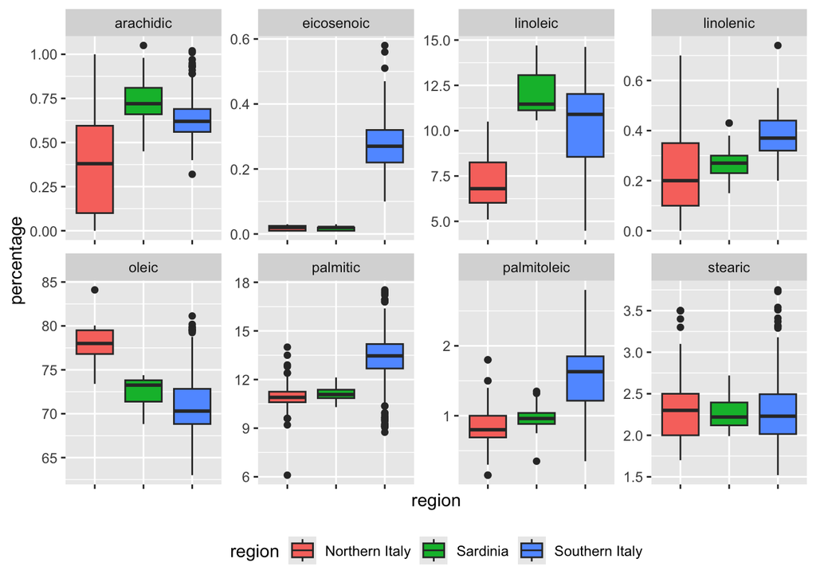

```r
olive %>% gather(fatty_acid, percentage, -region) %>%
  ggplot(aes(region, percentage, fill = region)) +
  geom_boxplot() +
  facet_wrap(~fatty_acid, scales = "free", ncol = 4) +
  theme(axis.text.x = element_blank(), legend.position="bottom")
```

### Paritions

This implies that we should be able to build an algorithm that predicts perfectly! Let’s try plotting the values for eicosenoic and linoleic.

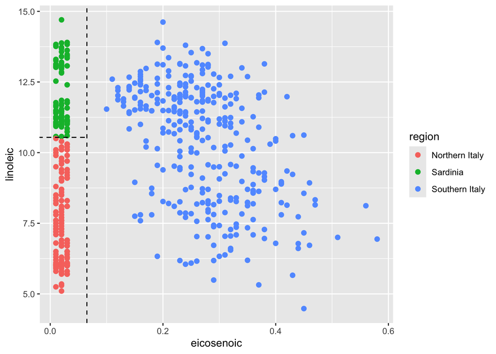

```r
olive %>%
  ggplot(aes(eicosenoic, linoleic, color = region)) +
  geom_point(size=2) +
  geom_vline(xintercept = 0.065, lty = 2) +
  geom_segment(x = -0.2, y = 10.54, xend = 0.065, yend = 10.54,
               color = "black", lty = 2)
```

### Decision tree

Let’s define a **decision rule**: If eicosenoic is larger than 0.065, predict Southern Italy. If not, then if linoleic is larger than $10.535$, predict Sardinia, otherwise predict Northern Italy. We can draw this decision tree:

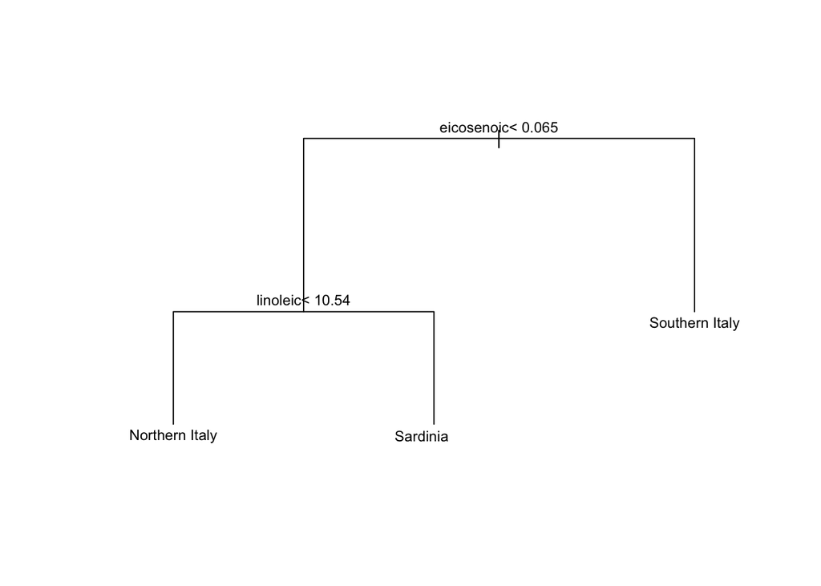

```r
train_rpart <- train(region ~ ., method = "rpart", data = olive)
plot(train_rpart$finalModel, margin = 0.1)
text(train_rpart$finalModel, cex = 0.75)
```

## Random Forests

### Summarize data

For this example we will use the Iris data in R

```r
datatable(iris)
```

|  | Sepal.Length | Sepal.Width | Petal.Length | Petal.Width | Species |
| --- | --- | --- | --- | --- | --- |
| 1 | 5.1 | 3.5 | 1.4 | 0.2 | setosa |
| 2 | 4.9 | 3 | 1.4 | 0.2 | setosa |
| 3 | 4.7 | 3.2 | 1.3 | 0.2 | setosa |
| 4 | 4.6 | 3.1 | 1.5 | 0.2 | setosa |
| 5 | 5 | 3.6 | 1.4 | 0.2 | setosa |
| 6 | 5.4 | 3.9 | 1.7 | 0.4 | setosa |
| 7 | 4.6 | 3.4 | 1.4 | 0.3 | setosa |
| 8 | 5 | 3.4 | 1.5 | 0.2 | setosa |
| 9 | 4.4 | 2.9 | 1.4 | 0.2 | setosa |
| 10 | 4.9 | 3.1 | 1.5 | 0.1 | setosa |

[output cut: 140 more lines]

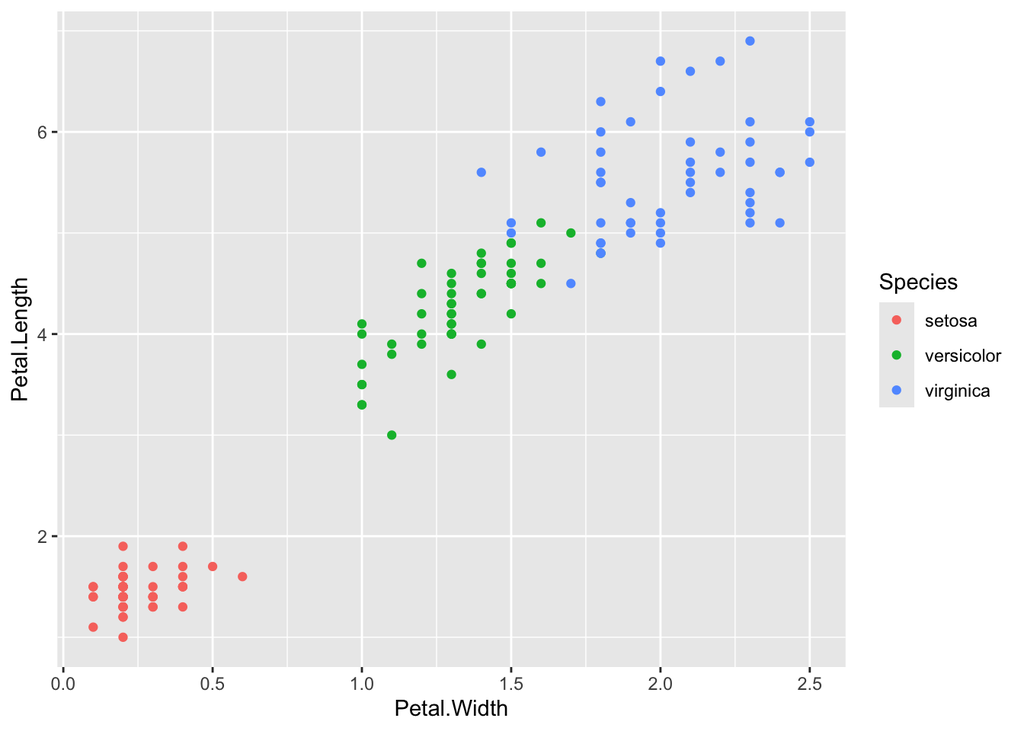

```r
iris %>% ggplot(aes(Petal.Width, Petal.Length, color = Species)) +
  geom_point()
```

### Select train/test

```r
set.seed(0)
test_index <- createDataPartition(iris$Species, times = 1,
                                  p = 0.3, list = FALSE)
iris_test <- iris[test_index, ]
iris_train <- iris[-test_index, ]
```

### Apply Random Forest

```r
iris_classifier <- randomForest(Species~., data = iris_train,
                    importance=T)
iris_classifier
```

```
##
## Call:
##  randomForest(formula = Species ~ ., data = iris_train, importance = T)
##                Type of random forest: classification
##                      Number of trees: 500
## No. of variables tried at each split: 2
##
##         OOB estimate of  error rate: 2.86%
## Confusion matrix:
##            setosa versicolor virginica class.error
## setosa         35          0         0  0.00000000
## versicolor      0         34         1  0.02857143
## virginica       0          2        33  0.05714286
```

### Results summary

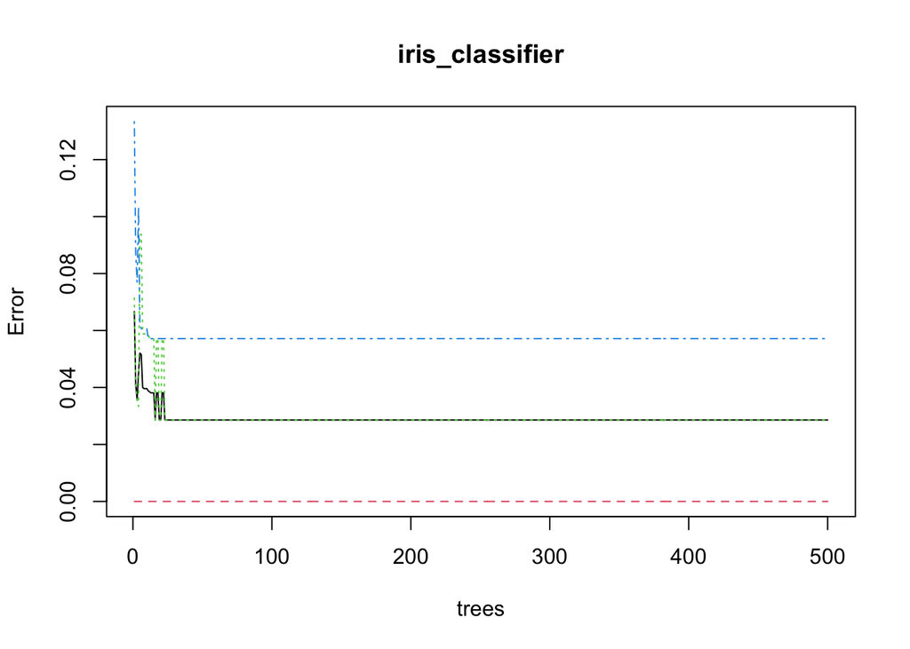

```r
plot(iris_classifier)
```

```r
importance(iris_classifier)
```

```
##                 setosa versicolor virginica MeanDecreaseAccuracy
## Sepal.Length  6.247640   8.383367  5.865249            10.618792
## Sepal.Width   4.490071   3.098781  3.295522             5.011737
## Petal.Length 22.641994  36.724624 25.382407            34.376688
## Petal.Width  21.561037  31.744843 24.616309            30.800022
##              MeanDecreaseGini
## Sepal.Length         5.527267
## Sepal.Width          1.786515
## Petal.Length        31.838258
## Petal.Width         30.130208
```

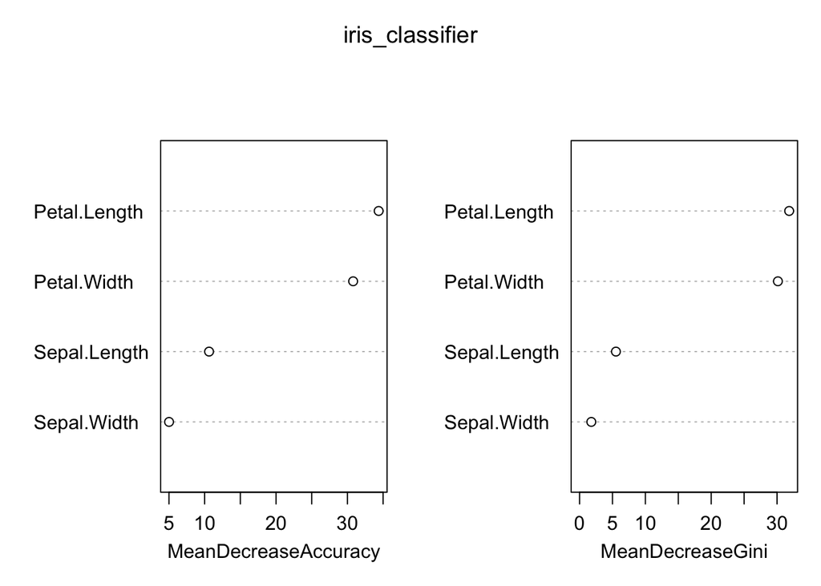

```r
varImpPlot(iris_classifier)
```

### Predictions

```r
predicted_table <- predict(iris_classifier, iris_test[,-5])
confusionMatrix(predicted_table, iris_test[,5])
```

```
## Confusion Matrix and Statistics
##
##             Reference
## Prediction   setosa versicolor virginica
##   setosa         15          0         0
##   versicolor      0         13         1
##   virginica       0          2        14
##
## Overall Statistics
##
##                Accuracy : 0.9333
##                  95% CI : (0.8173, 0.986)
##     No Information Rate : 0.3333
##     P-Value [Acc > NIR] : < 2.2e-16
##
##                   Kappa : 0.9
##
##  Mcnemar's Test P-Value : NA
##
## Statistics by Class:
##
##                      Class: setosa Class: versicolor Class: virginica
## Sensitivity                 1.0000            0.8667           0.9333
## Specificity                 1.0000            0.9667           0.9333
## Pos Pred Value              1.0000            0.9286           0.8750
## Neg Pred Value              1.0000            0.9355           0.9655
## Prevalence                  0.3333            0.3333           0.3333
## Detection Rate              0.3333            0.2889           0.3111
## Detection Prevalence        0.3333            0.3111           0.3556
## Balanced Accuracy           1.0000            0.9167           0.9333
```

## Additional practice

The `TBnanostring.rds` dataset contains gene expression measurements in the blood for 107 TB-related genes for 179 patients with either active tuberculosis infection (TB) or latent TB infection (LTBI) from one of [Dr. Johnson’s publications](https://pubmed.ncbi.nlm.nih.gov/35015839/). When you Load these data into R ( `TBnanostring <- readRDS("TBnanostring.rds")`) the TB status is found in the first column of the data frame, followed by the genes in the subsequent columns. The rows represent each individual patient.

Here is a UMAP clustering of the dataset, and plot the result using `ggplot`. The points are colored based on TB status.

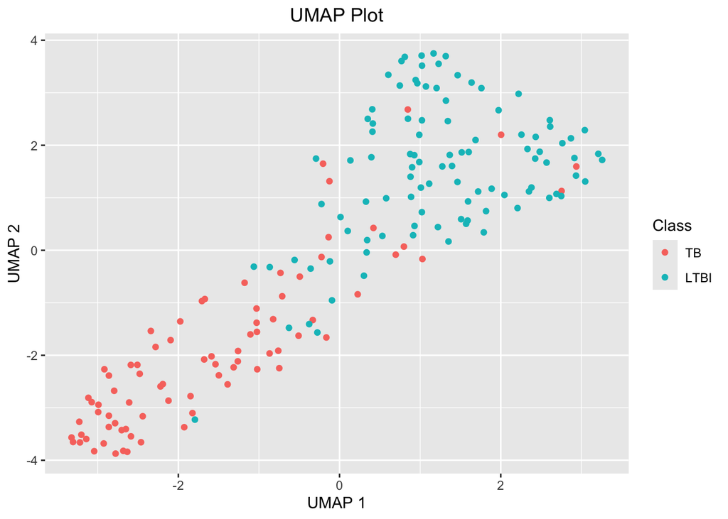

Split the dataset into “training” and “testing” sets using a 70/30 partition, using `set.seed(0)` and the `createDataPartition` function from the caret `package` (code is ‘hiding’ in the .Rmd file!). Apply the following machine learning methods to make a predictive biomarker to distinguish between the TB and control samples, use the `caret` package and cross validation to find the “finalModel” parameters to for each method.

Now, using the `caret::train()` function, apply the following machine learning methods to make a predictive biomarker to distinguish between the TB and control samples, use the `caret` package and cross validation to find the “finalModel” parameters to for each method. Provide any relevant/informative plots with your results.

1. Split the dataset into “training” and “testing” sets using a 70/30 partition (use `set.seed(0)` and the `caret::createDataPartition`).
2. Apply a Support Vector Machine to these data (try linear, radial, and polynomial kernels).
3. Apply a Random Forest Model to these data.
4. Compare the overall accuracy of the prediction methods for each of the machine learning tools in the previous problem. Which one performs the best?

(Note: the `TBnanostring.Rmd` and `TBnanostring.html` files provide suggested solutions for these analyses)